# DR. CARLOS MAURICIO PEREDO

## A/B PROTOTYPE TESTING

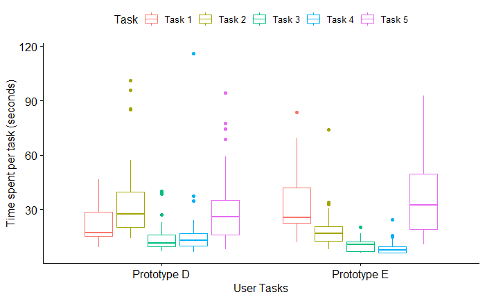

### PROJECT OVERVIEW

CLIENT  
Code.org (computer science education nonprofit)

GOAL  
Measure user performance for specific tasks across multiple different navigation prototypes.

PRIMARY TOOLS  
R & RStudio, RMarkdown, Shiny

BACKGROUND  
The client is redesigning their navigation to improve user performance across specific tasks. They have designed several navigation prototypes and conducted multiple rounds of user testing for each. The client needs insightful data analysis that converts data into actionable decision making.

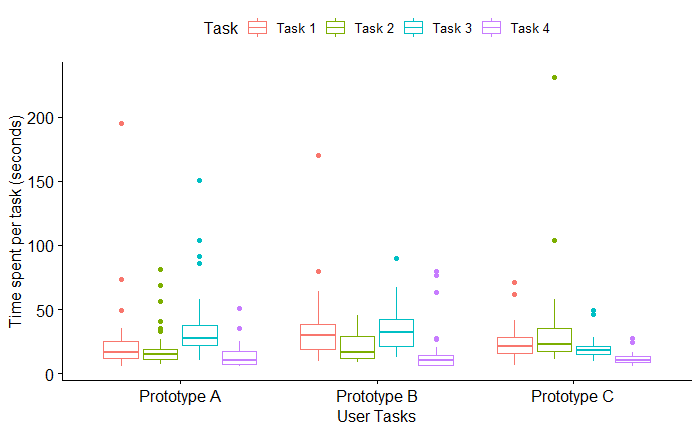

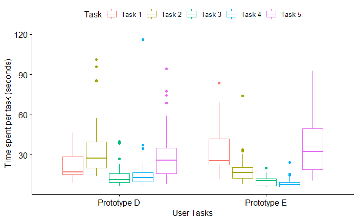

### CHALLENGES AND SOLUTIONS

**DATA OUTLIERS**

**The Challenge**: the client’s chosen user testing platform failed to identify key outliers, resulting in spurious preliminary conclusions  
**The Solution**: we identified and removed notable outliers, transformed the data to bolster its statistical power, and consulted on other details of the experimental design to maximize the data’s utility.

**DIVERSE SCREEN SIZES**

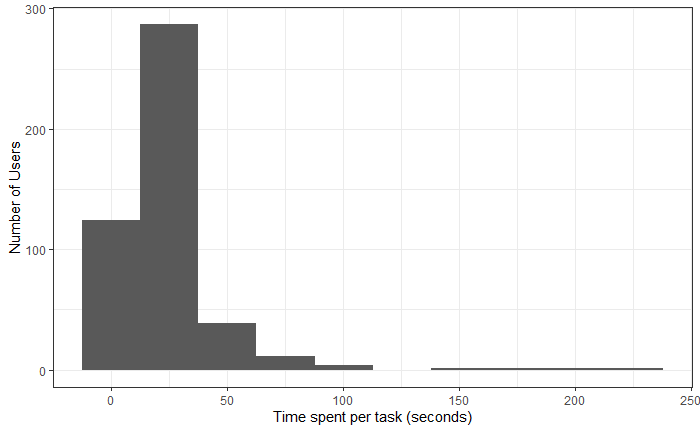

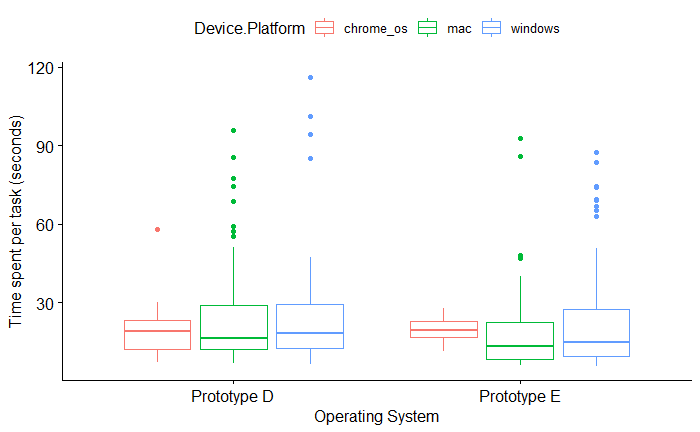

### NEXT STEPS

**ADVISE THE CLIENT**

Our results demonstrate that users performance is significantly improved by prototype E. We can confidently recommend Prototype E to the client if all other factors are equal.

**IDENTIFY OTHER KPIs**

The user testing reports include other metrics of interest, such as a 1-5 rating of how intuitive the user found the prototype. We will further explore the data to identify additional patterns that may inform the client’s choice.

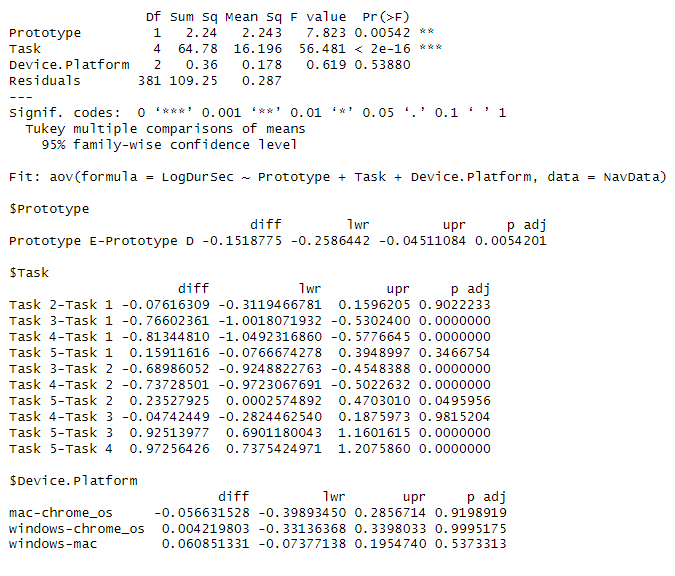

Back to Portfolio

Next: Discord Bot